# Binary Logistic Regression

## Introduction

- We have previously discussed continuous outcomes:
  - $y \sim N(\mu, \sigma^2)$
  - $y \sim \text{gamma}(\mu, \gamma)$
  - $y \sim \text{beta}(\alpha, \beta)$
- This week, we will consider categorical outcomes:
  - Binary
  - Multinomial

## Binary Logistic Regression

- We model binary outcomes using logistic regression,

$$\text{logit}(\pi) = \beta_0 + \beta_1 x_1 + ... + \beta_k x_k,$$

- where $\pi = \text{P}[Y = 1]$ = the probability of the outcome/event.
  - Recall, $\text{logit}()$ is the log-odds transformation. Here,
    $$\text{logit}(\pi) = \ln\left(\frac{\pi}{1-\pi}\right)$$

## Binary Logistic Regression

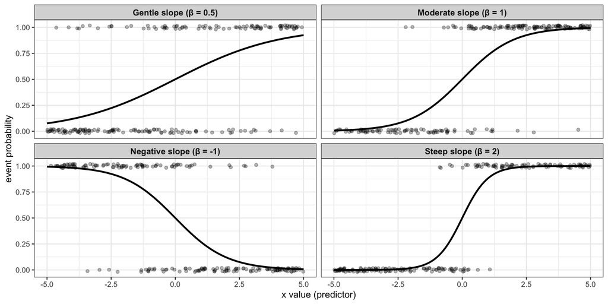

## Binary Logistic Regression

- Logistic regression is used specifically for *binary response variables* that take on two discrete values.
  - These are categorical outcomes typically coded as 0 and 1
  - Examples:
    - Customer churn (stayed vs. left)
    - Course outcome (pass vs. fail)
    - System status (operational vs. down)

## Binary Logistic Regression

- How is this different than beta regression?
  - Beta regression is used for *continuous response variables* that represent proportions or probabilities bounded between 0 and 1 (but not including the endpoints).
  - Examples:
    - Proportion of time spent on different activities
    - Percentage of correct answers on a test
    - Proportion of land covered by vegetation

## Binomial Distribution

- The Binomial distribution is a discrete probability distribution defined for the set $\{0, ..., n\}$.
  - The distribution gives the probability of observing a certain number of successes in $n$ independent Bernoulli trials.
- The Binomial distribution is characterized by $\pi = P[Y = 1]$, the probability of success, and $n$, the number of trials (sample size).
  - As $n$ increases, the distribution becomes more spread out.
  - Varying $\pi$ changes the shape of the distribution.
    - When $\pi$ is close to 0 or 1, the distribution is skewed.
    - When $\pi$ is around 0.5, the distribution is more symmetric.

## Binomial Distribution

- Same $n$, varying $\pi$:

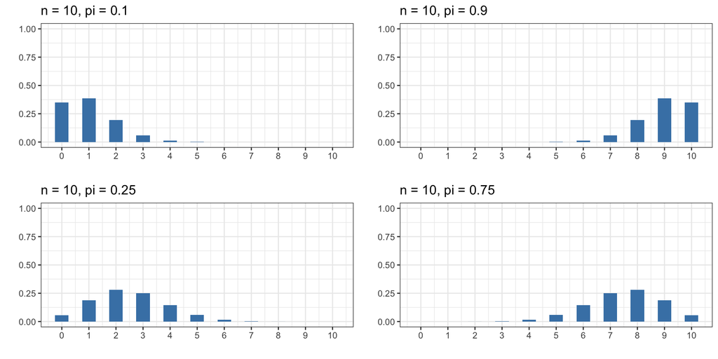

## Binomial Distribution

- Same $\pi$, varying $n$:

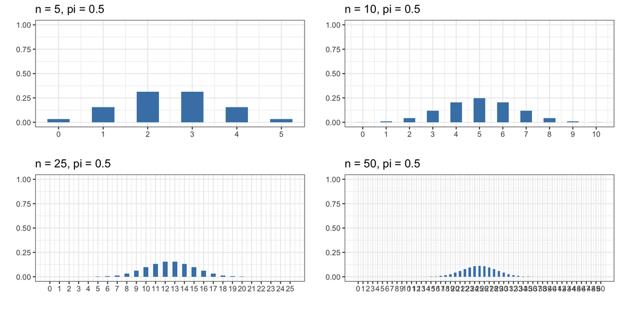

## Data Management

- Binary outcomes are typically coded as 0/1.
  - 0 = event did not occur
  - 1 = event did occur
- Some softwares allow us to get away with factor variables rather than numeric 0/1, but it is best practice to code binary outcomes as 0/1.
  - The code you will need will depend on how the original variable is coded.
  - Effectively, you will have something like

```r
dataset_name <- dataset_name %>%
  mutate(y = if_else(original_variable == "event occurred", 1, 0))
```

## Binary Logistic Regression (R)

- We will use the `glm()` function to perform binary logistic regression,

```r
m <- glm(y ~ x_1 + x_2 + ... + x_k,
         data = dataset_name,
         family = binomial(link = "logit"))
```

## Lecture Example Set Up

- Goofy and Max are gearing up for a huge audition. To make sure he’s ready, Max decides to test out a few different preparation plans leading up to the audition Each plan mixes a different approach to practicing, resting, and getting through the day.
- Some days Goofy insists on structure and early bedtimes, other days Max does things his own way. This leads to four plans:
  - Goofy-led plan
  - Max-led plan
  - Balanced plan
  - Chaotic plan

## Lecture Example Set Up

- Each day, Max tracks a few behaviors he thinks might affect how well things go:
  - Hours of practice he gets in
  - Hours of sleep the night before
  - Caffeine intake (mg)
  - Confidence level (0–10)
- Max then records if he nailed the (practice) audition for that day.

## Lecture Example Set Up

- Pulling in the data,

```r
max <- read_csv("https://raw.githubusercontent.com/samanthaseals/SDSII/refs/heads/main/files/data/lectures/W5_max.csv")
max %>% head()
```

| day | nailed_audition | made_it_to_concert | plan | practice_hours | sleep_hours | caffeine_mg | confidence |
| --- | --- | --- | --- | --- | --- | --- | --- |
| 1 | 1 | 1 | Max | 2.6 | 5.9 | 163 | 7.1 |
| 2 | 0 | 1 | Goofy | 0.7 | 5.7 | 185 | 5.8 |
| 3 | 1 | 1 | Balanced | 4.2 | 7.8 | 183 | 4.6 |
| 4 | 1 | 1 | Balanced | 0.8 | 9.5 | 79 | 9.1 |
| 5 | 1 | 0 | Goofy | 1.6 | 5.1 | 217 | 8.6 |
| 6 | 0 | 1 | Balanced | 1.4 | 7.3 | 61 | 6.5 |

## Example 1: Binary Logistic Regression

- Let’s model whether Max nailed the (practice) audition (`nailed_audition`) based on the plan followed, hours of practice, and hours of sleep.

```r
m1 <- glm(nailed_audition ~ plan + practice_hours + sleep_hours,
         data = max,
         family = binomial(link = "logit"))
m1 %>% tidy()
```

| term | estimate | std.error | statistic | p.value |
| --- | --- | --- | --- | --- |
| (Intercept) | -4.1686058 | 0.8132543 | -5.125833 | 2.962245e-07 |
| planChaotic | -1.4096353 | 0.4048186 | -3.482141 | 4.974215e-04 |
| planGoofy | -0.6619264 | 0.3056442 | -2.165677 | 3.033592e-02 |
| planMax | -0.3138744 | 0.3040380 | -1.032353 | 3.019070e-01 |
| practice_hours | 0.6478403 | 0.1153131 | 5.618098 | 1.930713e-08 |
| sleep_hours | 0.4031619 | 0.1014129 | 3.975452 | 7.024584e-05 |

## Example 1: Binary Logistic Regression

- Our resulting model is as follows,

```r
m1 %>% coefficients()
```

```
   (Intercept)    planChaotic      planGoofy        planMax practice_hours
    -4.1686058     -1.4096353     -0.6619264     -0.3138744      0.6478403
   sleep_hours
     0.4031619
```

$$\ln \left( \frac{\hat{\pi}}{1-\hat{\pi}} \right) = -4.17 - 1.41 \text{ C} -0.66 \text{ G} - 0.31 \text{ M} + 0.65 \text{ prac} + 0.40 \text{ sleep}$$

## Interpreting the Model

- Recall the binary logistic regression model,

$$\ln \left( \frac{\pi}{1-\pi} \right) = \beta_0 + \beta_1 x_1 + ... + \beta_k x_k,$$

- We are modeling the log odds, which are not intuitive with interpretations.
  - Interpreting $\hat{\beta}_i$, it is an *additive* effect on the *log odds*.
- To be able to discuss the odds, we will “undo” the natural log by exponentiation.
  - When interpreting $e^{\hat{\beta}_i}$, it is a *multiplicative* effect on the *odds*.
- Thus, when interpreting the slope for $x_i$, we will look at the *odds ratio*, $e^{\hat{\beta}_i}$.

## Interpreting the Model

- Why is it a multiplicative effect?

$$\begin{align*}
\ln \left( \frac{\pi}{1-\pi} \right) &= \beta_0 + \beta_1 x_1 + ... + \beta_k x_k \\
\exp\left\{ \ln \left( \frac{\pi}{1-\pi} \right) \right\} &= \exp\left\{ \beta_0 + \beta_1 x_1 + ... + \beta_k x_k \right\} \\
\frac{\pi}{1-\pi} &= e^{\beta_0} e^{\beta_1 x_1} \cdots e^{\beta_k x_k}
\end{align*}$$

## Interpreting the Model

- For continuous predictors:
  - For a 1 [unit of predictor] increase in [predictor name], the odds of [outcome] are multiplied by [$e^{\hat{\beta}_i}$].
  - For a 1 [unit of predictor] increase in [predictor name], the odds of [outcome] are [increased or decreased] by [100(e$^{\hat{\beta}_i}$-1)% or 100(1-e$^{\hat{\beta}_i}$)%].
- For categorical predictors:
  - As compared to [the reference group], the odds of [outcome] for [group that the slope belongs to] are multiplied by [$e^{\hat{\beta}_i}$].
  - As compared to [the reference group], the odds of [outcome] for [group that the slope belongs to] are [increased or decreased] by [100(e$^{\hat{\beta}_i}$-1)% or 100(1-e$^{\hat{\beta}_i}$)%].

## Odds Ratios (R)

- We can request the odds ratios directly out of `tidy()`,

```r
model %>% tidy(conf.int = TRUE, exponentiate = TRUE)
```

- Note: if you have an interaction term in the model, you must stratify your interpretations by the levels of the interacting variable(s) before exponentiating.

## Example 1: Interpreting the Model

- Revisiting our results,

```r
m1 %>% tidy(conf.int = TRUE, exponentiate = TRUE)
```

| term | estimate | std.error | statistic | p.value | conf.low | conf.high |
| --- | --- | --- | --- | --- | --- | --- |
| (Intercept) | 0.01547382 | 0.8132543 | -5.125833 | 2.962245e-07 | 0.002998563 | 0.07322081 |
| planChaotic | 0.24423233 | 0.4048186 | -3.482141 | 4.974215e-04 | 0.107434234 | 0.52919406 |
| planGoofy | 0.51585662 | 0.3056442 | -2.165677 | 3.033592e-02 | 0.281277166 | 0.93448640 |
| planMax | 0.73061076 | 0.3040380 | -1.032353 | 3.019070e-01 | 0.401296504 | 1.32462276 |
| practice_hours | 1.91140826 | 0.1153131 | 5.618098 | 1.930713e-08 | 1.537326570 | 2.41770254 |
| sleep_hours | 1.49654918 | 0.1014129 | 3.975452 | 7.024584e-05 | 1.231117798 | 1.83384554 |

## Example 1: Interpreting the Model

- Interpreting our model,

```r
round(exp(coefficients(m1)), 2)
```

```
   (Intercept)    planChaotic      planGoofy        planMax practice_hours
          0.02           0.24           0.52           0.73           1.91
   sleep_hours
          1.50
```

## Example 1: Interpreting the Model

- Interpreting our model,

```r
round(exp(coefficients(m1)), 2)
```

```
   (Intercept)    planChaotic      planGoofy        planMax practice_hours
          0.02           0.24           0.52           0.73           1.91
   sleep_hours
          1.50
```

- For a 1 hour increase in practice, the odds of nailing the audition are multiplied by 1.91. This is an increase of 91%.
- For a 1 hour increase in sleep, the odds of nailing the audition are multiplied by 1.50. This is an increase of 50%.

## Reporting Results

- When reporting results from models that *do not* use the identity link (i.e., non-normal distributions), we go from reporting $\hat{\beta}_i$ to reporting $e^{\hat{\beta}_i}$.

| Predictor | OR (95% CI for OR) | *p*-value |
| --- | --- | --- |
| variable 1 | OR<sub>1</sub> (LL<sub>1</sub>, UL<sub>1</sub>) | *p*<sub>1</sub> |
| variable 2 | OR<sub>2</sub> (LL<sub>2</sub>, UL<sub>2</sub>) | *p*<sub>2</sub> |
| … | … | … |
| variable *k* | OR<sub>*k*</sub> (LL<sub>*k*</sub>, UL<sub>*k*</sub>) | *p*<sub>*k*</sub> |

## Example 1: Reporting Results

- In our example,

[output not shown]

## Statistical Inference

- Our approach to determining significance remains the same.
  - For continuous and binary predictors, we can use the Wald test ($z$-test from `tidy()`).
  - For omnibus tests, we can use the likelihood ratio test (LRT).
    - Significance of regression line (full/reduced LRT).
    - Significance of categorical predictors with $c \ge 3$ levels (`car::Anova(type = 3)` or full/reduced LRT).
    - Interaction terms with categorical predictors with $c \ge 3$ levels (`car::Anova(type = 3)` or full/reduced LRT).

## Example 1: Significance of Regression Line

- In our example, we can test for significance of a regression line:

```r
m1_full <- glm(nailed_audition ~ plan + practice_hours + sleep_hours, data = max, family = binomial(link = "logit"))
m1_reduced <- glm(nailed_audition ~ 1, data = max, family = binomial(link = "logit"))
anova(m1_reduced, m1_full, test = "LRT")
```

|  | Resid. Df | Resid. Dev | Df | Deviance | Pr(>Chi) |
| --- | --- | --- | --- | --- | --- |
| 1 | 349 | 485.1002 | NA | NA | NA |
| 2 | 344 | 419.7071 | 5 | 65.39307 | 9.288794e-13 |

- Yes, this is a significant regression line ($p < 0.001$).

## Example 1: Significance of Predictors

- In our model, we have a categorical predictor with 4 levels – `car::Anova(type =3)` (or the full/reduced + `anova()` approach) is necessary.

```r
m1 %>% car::Anova(type = 3)
```

|  | LR Chisq | Df | Pr(>Chisq) |
| --- | --- | --- | --- |
| plan | 14.47214 | 3 | 2.328100e-03 |
| practice_hours | 38.85309 | 1 | 4.569303e-10 |
| sleep_hours | 16.84592 | 1 | 4.054040e-05 |

- Plan is a significant predictor ($p = 0.002$).
- Practice hours is a significant predictor ($p < 0.001$).
- Sleep hours is a significant predictor ($p < 0.001$).

## Example 2: Binary Logistic Regression

- Let’s now model whether Max nailed the audition (`nailed_audition`) based on the plan followed, hours of practice, hours of sleep, caffeine intake, and the interaction between hours of sleep and plan.

```r
m2 <- glm(nailed_audition ~ plan + practice_hours + sleep_hours + caffeine_mg + sleep_hours:plan,
         data = max,
         family = binomial(link = "logit"))
m2 %>% tidy(conf.int = TRUE, exponentiate = TRUE)
```

| term | estimate | std.error | statistic | p.value | conf.low | conf.high |
| --- | --- | --- | --- | --- | --- | --- |
| (Intercept) | 0.068505132 | 1.243335667 | -2.1561729 | 3.107017e-02 | 5.591798e-03 | 0.75086725 |
| planChaotic | 0.077153993 | 2.581930881 | -0.9922620 | 3.210697e-01 | 4.116259e-04 | 11.21246791 |
| planGoofy | 0.001817849 | 2.061416865 | -3.0610506 | 2.205618e-03 | 2.621979e-05 | 0.08985091 |
| planMax | 2.210520434 | 1.812240154 | 0.4377058 | 6.615996e-01 | 6.290944e-02 | 79.12918628 |
| practice_hours | 1.937787459 | 0.119718158 | 5.5258688 | 3.278590e-08 | 1.545414e+00 | 2.47255069 |
| sleep_hours | 1.233862962 | 0.160756273 | 1.3072576 | 1.911252e-01 | 9.044608e-01 | 1.70550032 |
| caffeine_mg | 0.999083411 | 0.001107399 | -0.8280749 | 4.076281e-01 | 9.968824e-01 | 1.00123151 |
| planChaotic:sleep_hours | 1.180326380 | 0.355625495 | 0.4661955 | 6.410756e-01 | 5.888357e-01 | 2.40601690 |
| planGoofy:sleep_hours | 2.201825692 | 0.285295991 | 2.7665544 | 5.665213e-03 | 1.282908e+00 | 3.95868422 |
| planMax:sleep_hours | 0.852783635 | 0.256053926 | -0.6219370 | 5.339833e-01 | 5.143283e-01 | 1.40978254 |

## Example 2: Significance of Regression Line

- Let’s make sure this is a significant model,

```r
m2_full <- glm(nailed_audition ~ plan + practice_hours + sleep_hours + caffeine_mg + sleep_hours:plan, data = max, family = binomial(link = "logit"))
m2_reduced <- glm(nailed_audition ~ 1, data = max, family = binomial(link = "logit"))
anova(m2_reduced, m2_full, test = "LRT")
```

|  | Resid. Df | Resid. Dev | Df | Deviance | Pr(>Chi) |
| --- | --- | --- | --- | --- | --- |
| 1 | 349 | 485.1002 | NA | NA | NA |
| 2 | 340 | 407.1837 | 9 | 77.91642 | 4.186586e-13 |

- Yes, this is a significant regression line ($p < 0.001$); at least one of the slopes are non-zero.

## Example 2: Significance of Predictors

- In our model, we have a categorical predictor with 4 levels – `car::Anova(type =3)` (or the full/reduced + `anova()` approach) is necessary.

```r
m2 %>% car::Anova(type = 3)
```

|  | LR Chisq | Df | Pr(>Chisq) |
| --- | --- | --- | --- |
| plan | 13.9683553 | 3 | 2.948545e-03 |
| practice_hours | 37.5381696 | 1 | 8.964148e-10 |
| sleep_hours | 1.7477286 | 1 | 1.861625e-01 |
| caffeine_mg | 0.6928492 | 1 | 4.051969e-01 |
| plan:sleep_hours | 12.0042013 | 3 | 7.368783e-03 |

- The interaction between plan and sleep hours is a significant predictor ($p = 0.007$).

## Example 2: Significance of Predictors

- In our model, we have a categorical predictor with 4 levels – the full/reduced + `anova()` approach (or `car::Anova(type =3)`) is necessary.

```r
m2_full <- glm(nailed_audition ~ plan + practice_hours + sleep_hours + caffeine_mg + sleep_hours:plan, data = max, family = binomial(link = "logit"))
m2_reduced <- glm(nailed_audition ~ plan + practice_hours + sleep_hours + caffeine_mg, data = max, family = binomial(link = "logit"))
anova(m2_reduced, m2_full, test = "LRT")
```

|  | Resid. Df | Resid. Dev | Df | Deviance | Pr(>Chi) |
| --- | --- | --- | --- | --- | --- |
| 1 | 343 | 419.1879 | NA | NA | NA |
| 2 | 340 | 407.1837 | 3 | 12.0042 | 0.007368783 |

- The interaction between plan and sleep hours is a significant predictor ($p = 0.007$).

## Example 2: Significance of Predictors

- The interaction between plan and sleep hours is a significant predictor ($p = 0.007$).

```r
m2 %>% car::Anova(type = 3)
```

|  | LR Chisq | Df | Pr(>Chisq) |
| --- | --- | --- | --- |
| plan | 13.9683553 | 3 | 2.948545e-03 |
| practice_hours | 37.5381696 | 1 | 8.964148e-10 |
| sleep_hours | 1.7477286 | 1 | 1.861625e-01 |
| caffeine_mg | 0.6928492 | 1 | 4.051969e-01 |
| plan:sleep_hours | 12.0042013 | 3 | 7.368783e-03 |

- What does this actually mean?
  - The effect of sleep hours on the odds of nailing the audition depends on which plan is being followed.
    - i.e., $\hat{\beta}_{\text{sleep hours}}$ is not constant across all plans.
  - We will *stratify* by plan when interpreting the effect of sleep hours.

## Example 2: Odds Ratios

- Using the original coefficients, we can stratify by plan:

```r
coefficients(m2)
```

```
            (Intercept)             planChaotic               planGoofy
          -2.6808466148           -2.5619519420           -6.3101012814
                planMax          practice_hours             sleep_hours
           0.7932279783            0.6615468372            0.2101498676
            caffeine_mg planChaotic:sleep_hours   planGoofy:sleep_hours
          -0.0009170096            0.1657909939            0.7892868764
    planMax:sleep_hours
          -0.1592494154
```

- Then, for each type of plan, the intercept and slope for *sleep hours* is as follows:

| Plan | Intercept | Sleep Hours Slope | Sleep Hours OR |
| --- | --- | --- | --- |
| Balanced | -2.68 | 0.21 | exp(0.21) = 1.23 |
| Chaotic | -2.68 - 2.56 = -5.24 | 0.21 + 0.17 = 0.38 | exp(0.38) = 1.46 |
| Goofy | -2.68 -6.31 = -8.99 | 0.21 + 0.79 = 1.00 | exp(1.00) = 2.72 |
| Max | -2.68 + 0.79 = -1.89 | 0.21 - 0.16 = 0.05 | exp(0.05) = 1.05 |

## Example 2: Interpreting the Model

- Now let’s interpret the coefficients,

| Plan | Intercept | Sleep Hours Slope | Sleep Hours OR |
| --- | --- | --- | --- |
| Balanced | -2.68 | 0.21 | exp(0.21) = 1.23 |
| Chaotic | -2.68 - 2.56 = -5.24 | 0.21 + 0.17 = 0.38 | exp(0.38) = 1.46 |
| Goofy | -2.68 -6.31 = -8.99 | 0.21 + 0.79 = 1.00 | exp(1.00) = 2.72 |
| Max | -2.68 + 0.79 = -1.89 | 0.21 - 0.16 = 0.05 | exp(0.05) = 1.05 |

- Interpreting the odds ratios for *sleep hours*:
  - Balanced plan: For a 1 hour increase in sleep, the odds of nailing the audition are multiplied by 1.23 (a 23% increase).
  - Chaotic plan: For a 1 hour increase in sleep, the odds of nailing the audition are multiplied by 1.46 (a 46% increase).

## Example 2: Interpreting the Model

- Now let’s interpret the coefficients,

| Plan | Intercept | Sleep Hours Slope | Sleep Hours OR |
| --- | --- | --- | --- |
| Balanced | -2.68 | 0.21 | exp(0.21) = 1.23 |
| Chaotic | -2.68 - 2.56 = -5.24 | 0.21 + 0.17 = 0.38 | exp(0.38) = 1.46 |
| Goofy | -2.68 -6.31 = -8.99 | 0.21 + 0.79 = 1.00 | exp(1.00) = 2.72 |
| Max | -2.68 + 0.79 = -1.89 | 0.21 - 0.16 = 0.05 | exp(0.05) = 1.05 |

- Interpreting the odds ratios for *sleep hours*:
  - Goofy-led plan: For a 1 hour increase in sleep, the odds of nailing the audition are multiplied by 2.72 (a 172% increase).
  - Max-led plan: For a 1 hour increase in sleep, the odds of nailing the audition are multiplied by 1.05 (a 5% increase).

## Example 2: Interpreting the Model

- Reviewing what’s in the model,

```r
round(exp(coefficients(m2)), 2)
```

```
            (Intercept)             planChaotic               planGoofy
                   0.07                    0.08                    0.00
                planMax          practice_hours             sleep_hours
                   2.21                    1.94                    1.23
            caffeine_mg planChaotic:sleep_hours   planGoofy:sleep_hours
                   1.00                    1.18                    2.20
    planMax:sleep_hours
                   0.85
```

## Examples 1 and 2: Model Fit

- We can still use AIC and BIC to examine/compare model fit.
- Let’s use the BIC to determine if `m1` or `m2` fit the model better.

```r
m1 %>% BIC()
```

```
[1] 454.8547
```

```r
m2 %>% BIC()
```

```
[1] 465.7631
```

- Interestingly, the `m1` fits the data better, despite the interaction being significant.
  - This suggests that the added complexity of `m2` is not worth the slight increase in model fit.

## Wrap Up

- In this lecture, we have introduced binary logistic regression.
  - Binary logistic regression is appropriate for binary outcomes.
- We again saw the logit link function.
  - We interpret coefficients as multiplicative effects on the *odds* of the event happening.
- In the next lecture, we will review multinomial logistic regression.